# Смешаные линейные модели для счетных данных

## Вы узнаете

- Как анализировать данные, в которых зависимая переменная - счетная величина, и есть случайные факторы

### Вы сможете

- Построить линейные модели с пуассоновским и отрицательным биномиальным распределением отклика
- Сможете проверить смешанные модели на избыточность дисперсии
- Научитесь проверять наличие нелинейных паттернов в остатках

## Cмешанные модели для счетных данных

## От чего завист призывный крик совят?

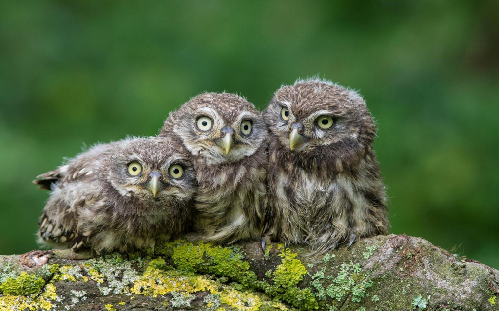

фото с http://www.mobilmusic.ru/wallpaper.php?id=1343149

Данные из Roulin & Bersier 2007, пример из кн. Zuur et al., 2007

Будем моделировать зависимость числа криков совят (SiblingNegotiation) от многих факторов

- `FoodTreatment` - тритмент (сытые или голодные)
- `SexParent` - пол родителя
- `FoodTreatment x SexParent`
- `ArrivalTime` - время прибытия родителя
- `ArrivalTime х SexParent`
- `Nest` - гнездо

## Загружаем пакеты и данные

```r
# Загружаем нужные пакеты
library(downloader) # для загрузки файлов из интернета
library(ggplot2)
theme_set(theme_bw(base_size = 14) + theme(legend.key = element_blank()))
update_geom_defaults("point", list(shape = 19))
library(gridExtra)

# Загружаем данные из интернета и сохраняем в файл, если его еще нет
url <- "https://raw.githubusercontent.com/varmara/linmodr/master/16-glmm-pois-negbin/Owls_Roulin_Bersier_2007.csv"
filename <- "data/Owls_Roulin_Bersier_2007.csv"
if (!file.exists(filename)) download(url, filename)
```

## Знакомство с данными

```r
Owls <- read.delim("data/Owls_Roulin_Bersier_2007.csv")
str(Owls)
```

```
## 'data.frame':    599 obs. of  8 variables:
##  $ Nest              : Factor w/ 27 levels "AutavauxTV","Bochet",..: 1 1 1 1 1 1 1 1 1 1 ...
##  $ FoodTreatment     : Factor w/ 2 levels "Deprived","Satiated": 1 2 1 1 1 1 1 2 1 2 ...
##  $ SexParent         : Factor w/ 2 levels "Female","Male": 2 2 2 2 2 2 2 1 2 1 ...
##  $ ArrivalTime       : num  22.2 22.4 22.5 22.6 22.6 ...
##  $ SiblingNegotiation: int  4 0 2 2 2 2 18 4 18 0 ...
##  $ BroodSize         : int  5 5 5 5 5 5 5 5 5 5 ...
##  $ NegPerChick       : num  0.8 0 0.4 0.4 0.4 0.4 3.6 0.8 3.6 0 ...
##  $ logBroodSize      : num  1.61 1.61 1.61 1.61 1.61 ...
```

```r
# SiblingNegotiation - число криков совят - заменим на более короткое название
Owls$NCalls <- Owls$SiblingNegotiation
# Число пропущенных значений
sum(!complete.cases(Owls))
```

```
## [1] 0
```

## Есть ли выбросы?

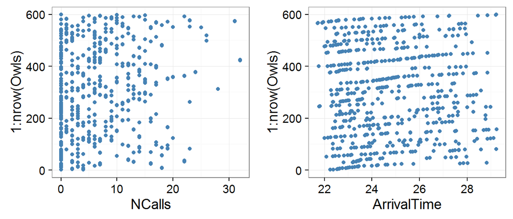

```r
# Есть ли наблюдения-выбросы? строим dot-plot
dotplot <- ggplot(Owls, aes(y = 1:nrow(Owls))) + geom_point(colour = "steelblue")

grid.arrange(dotplot + aes(x = NCalls),
  dotplot + aes(x = ArrivalTime), nrow = 1)
```

- Выбросов нет

## Различаются ли гнезда?

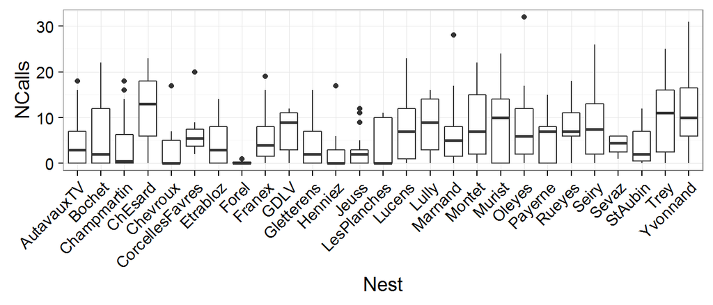

```r
ggplot(Owls, aes(x = Nest, y = NCalls)) + geom_boxplot() + theme(axis.text.x = element_text(angle = 45, hjust = 1))
```

- Гнезд много, они различаются. Можно и нужно учесть как случайный эффект

## Сколько наблюдений в каждом гнезде?

```r
table(Owls$Nest)
```

```
##
##      AutavauxTV          Bochet     Champmartin         ChEsard
##              28              23              30              20
##        Chevroux CorcellesFavres        Etrabloz           Forel
##              10              12              34               4
##          Franex            GDLV      Gletterens         Henniez
##              26              10              15              13
##           Jeuss     LesPlanches          Lucens           Lully
##              19              17              29              17
##         Marnand          Montet          Murist          Oleyes
##              27              41              24              52
##         Payerne          Rueyes           Seiry           Sevaz
##              25              17              26               4
##         StAubin            Trey        Yvonnand
##              23              19              34
```

- Хорошо, что наблюдений в каждом гнезде много. Только в двух по четыре - не очень.

## Как распределен отклик?

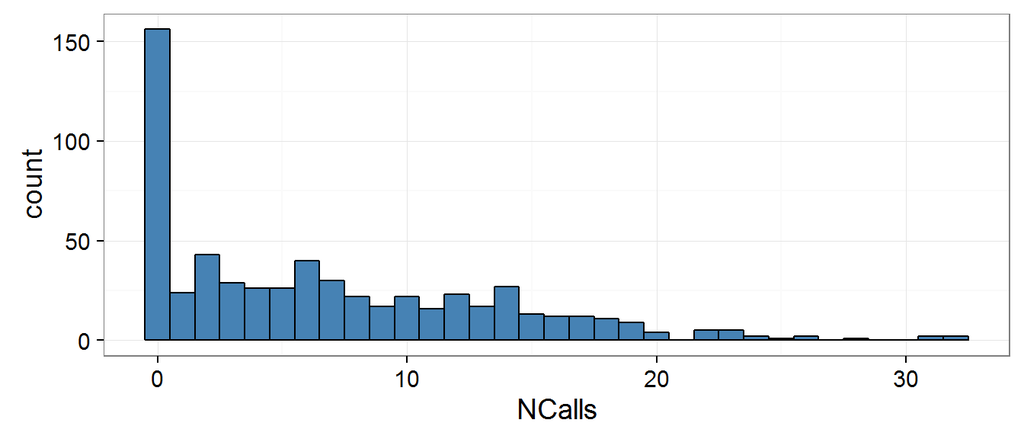

```r
ggplot(Owls, aes(x = NCalls)) + geom_histogram(binwidth = 1, fill = "steelblue", colour = "black")
```

- Напоминает распределение Пуассона

## Сколько нулей?

```r
sum(Owls$NCalls == 0)/nrow(Owls)
```

```
## [1] 0.26
```

- 26% нулей

## Какого размера выводки в гнездах?

Это нужно учесть, потому что чем больше выводок, тем больше птенцов будут разговаривать.

```
## [1] 1 7
```

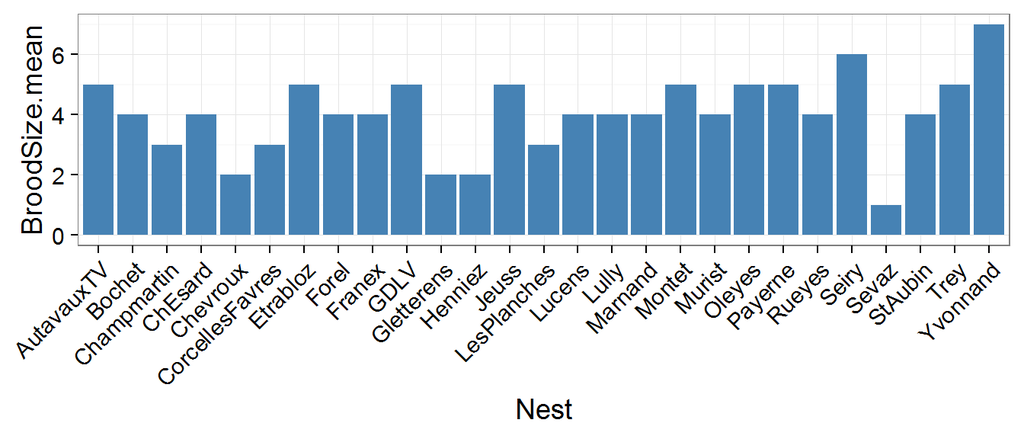

- Выводки разные. В пуассоновской glmer() это можно откорректировать при помощи offset. Сделаем offset(logBroodSize)

## Боксплоты для дискретных факторов

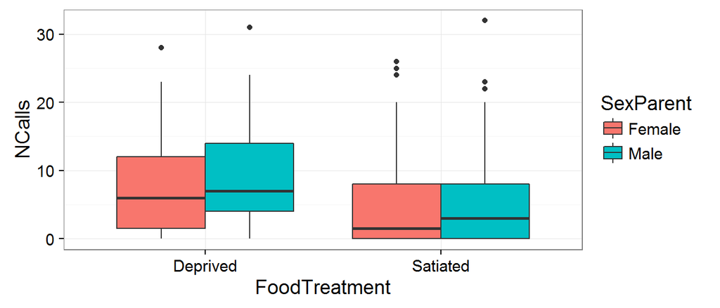

```r
ggplot(Owls, aes(y = NCalls, x = FoodTreatment, fill = SexParent)) + geom_boxplot()
```

- Подозрительно, возможно, есть взаимодействие.

## Может быть есть взаимодействие?

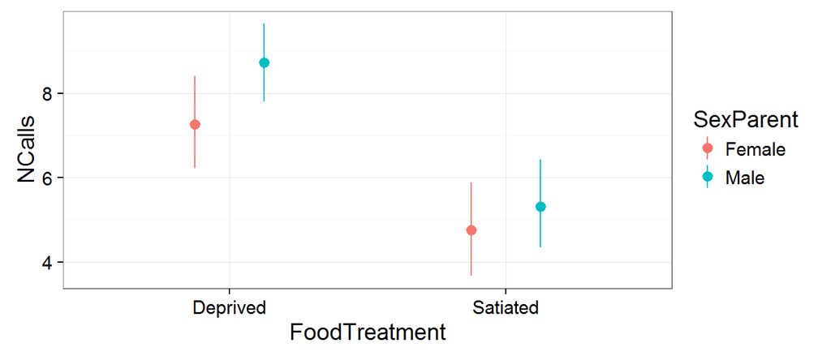

```r
ggplot(Owls) + stat_summary(aes(x = FoodTreatment, y = NCalls, colour = SexParent), fun.data = "mean_cl_boot", position = position_dodge(width = 0.5))
```

- Похоже, что может быть взаимодействие

## Задание: Постройте такой график

Нарисуем все данные для будущей модели

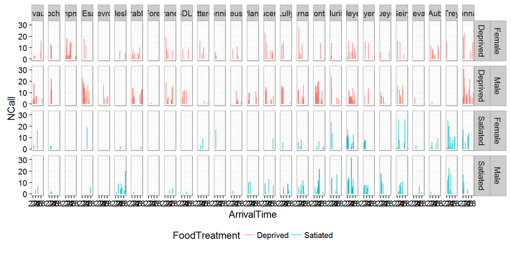

- Птенцы больше орут, если голодали прошлой ночью. И возможно, орут у самцов

## Код для графика

```r
ggplot(Owls) + geom_segment(aes(x = ArrivalTime, y = 0, xend = ArrivalTime, yend = NCalls, colour = FoodTreatment)) + facet_grid(FoodTreatment + SexParent ~ Nest) + ylab("NCall") + theme(legend.position = "bottom")
```

## Колинеарность

```r
M0 <- lm(NCalls ~ SexParent + FoodTreatment + ArrivalTime, data = Owls)
library(car)
vif(M0)
```

```
##     SexParent FoodTreatment   ArrivalTime
##        1.0036        1.0044        1.0024
```

- ок

## Линейная модель с пуассоновским распределением остатков

\[NCalls_{ij} = e^{\beta_0 + \beta_{1}SexP_{M} + \beta_{2}FoodT_{S} + \beta_{3}ArrivalT + \beta_{4} SexP_{M}:FoodT_{S} + \beta_{5}SexP{M}:ArrivalT + log(BroodSize) + a_{i} + \epsilon_{ij}}\]

- \(NCalls \sim \boldsymbol{P}(\mu_{ij})\) — отклик подчиняется распределению Пуассона с параметром \(\mu\)
- \(E(NCalls_{ij}) = \mu_{ij}\)
- \(var(NCalls_{ij}) = \mu_{ij}\)
- \(ln(\mu_{ij}) = \eta_{ij}\) — функция связи — логарифм

\(\begin{array}{l} \eta_{ij} = \beta_0 + \beta_{1}SexParent_{M} + \beta_{2}FoodTreatment_{S} + \beta_{3}ArrivalTime + \\ + \beta_{4} SexParent_{M}:FoodTreatment_{S} + \beta_{5}SexParent{M}:ArrivalTime + log(BroodSize) + \\ + a_{i} + \epsilon_{ij} \end{array}\)

- \(a_{i}\sim N(0, \sigma^2_{Nest})\) — случайный эффект гнезда (intercept)
- \(\epsilon_{ij} \sim N(0, \sigma^2)\) — остатки модели
- \(i\) — гнездо
- \(j\) — наблюдение

## Подберем линейную модель с пуассоновским распределением остатков

```r
library(lme4)
M1 <- glmer(NCalls ~ SexParent * FoodTreatment + SexParent * ArrivalTime + offset(logBroodSize) + (1 | Nest), family = "poisson", data = Owls)
```

Смешанная модель с распределением пуассона не сходится. Один из возможных вариантов выхода - стандартизация предикторов

## Стандартизируем непрерывные предикторы

У нас только один непрерывный предиктор

```r
Owls$ArrivalTime_std <- (Owls$ArrivalTime - mean(Owls$ArrivalTime)) / sd(Owls$ArrivalTime)

M1 <- glmer(NCalls ~ SexParent * FoodTreatment + SexParent * ArrivalTime_std + offset(logBroodSize) + (1 | Nest), family = "poisson", data = Owls)
```

Эта модель сходится

## Задание:

Проверьте модель M1 на избыточность дисперсии

## Избыточность дисперсии (Overdispersion)

```r
R_M1 <- resid(M1, type = "pearson") # Пирсоновские остатки
N <- nrow(Owls) # Объем выборки
p <- length(fixef(M1)) + 1   # Число параметров в модели (сигма для гнезда)
df <- (N - p) # число степенейсвободы
fi <- sum(R_M1^2) /df  #Величина fi показывает во сколько раз в среднем sigma > mu для данной модели
fi
```

```
## [1] 5.46
```

- Избыточность дисперсии.

## Почему здесь могла быть избыточность дисперсии?

- Отскакивающие значения –> убрать
- Пропущены ковариаты или взаимодействия предикторов –> добавить
- Наличие внутригрупповых корреляций (нарушение независимости выборок) –> другие случайные эффекты?
- Нелинейная взаимосвязь между ковариатами и зависимой переменной –> GAMM
- Неверно подобрана связывающая функция –> заменить
- Количество нулей больше, чем предсказывает распределение Пуассона (Zero inflation) –> ZIP
- Просто большая дисперсия? –> NB

## Диагностика модели

График остатков

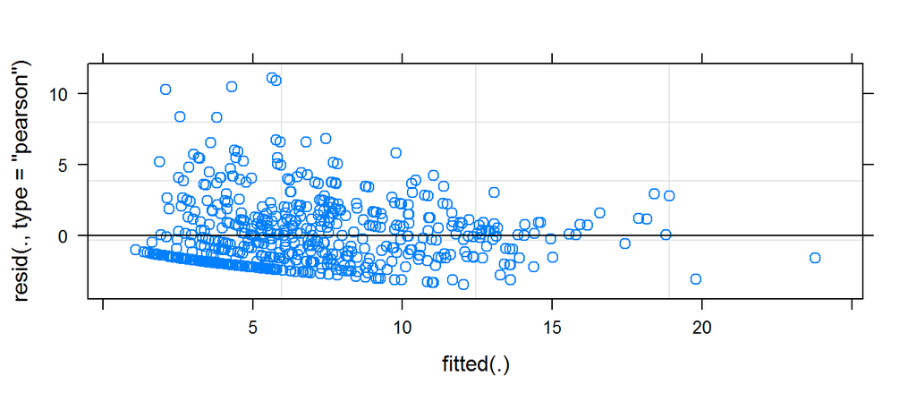

```r
plot(M1)
```

## Более удобный график остатков

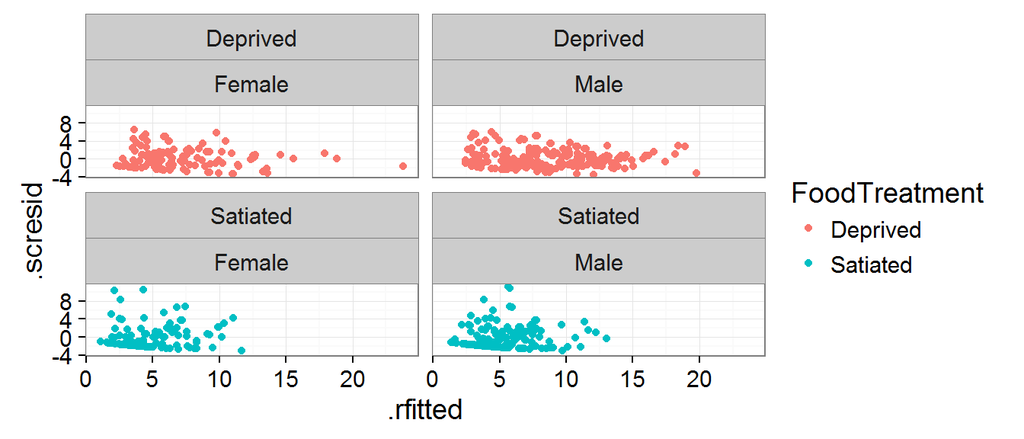

```r
M1_diag <- fortify(M1)
M1_diag$.rfitted <- predict(M1, type = "response")

gg_resid <- ggplot(M1_diag, aes(x = .rfitted, y = .scresid, colour = FoodTreatment)) + geom_point() + facet_wrap(~ FoodTreatment + SexParent)
gg_resid
```

- Есть большие остатки

## Есть ли еще какие-то паттерны в остатках?

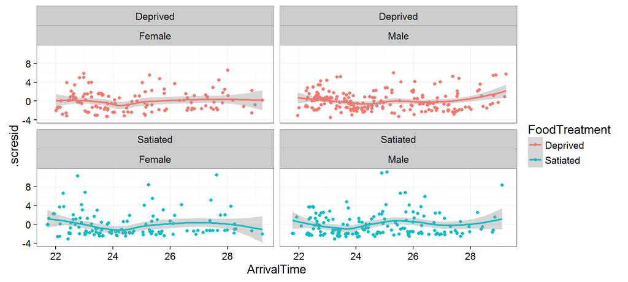

```r
# gg_resid %+% aes(x = ArrivalTime)
gg_resid %+% aes(x = ArrivalTime) + geom_smooth()
```

- Есть намек на нелинейность. Возможно, нужен GAMM

## Проверяем, есть ли нелинейный паттерн в остатках

```r
library(mgcv)
nonlin1 <- gam(.scresid ~ s(ArrivalTime), data = M1_diag)
summary(nonlin1)
```

```
##
## Family: gaussian
## Link function: identity
##
## Formula:
## .scresid ~ s(ArrivalTime)
##
## Parametric coefficients:
##             Estimate Std. Error t value Pr(>|t|)
## (Intercept)  -0.0111     0.0920   -0.12      0.9
##
## Approximate significance of smooth terms:
##                 edf Ref.df    F   p-value
## s(ArrivalTime) 7.15    8.2 5.04 0.0000039 ***
## ---
## Signif. codes:  0 '***' 0.001 '**' 0.01 '*' 0.05 '.' 0.1 ' ' 1
##
## R-sq.(adj) =  0.0618   Deviance explained =  7.3%
## GCV = 5.1414  Scale est. = 5.0715    n = 599
```

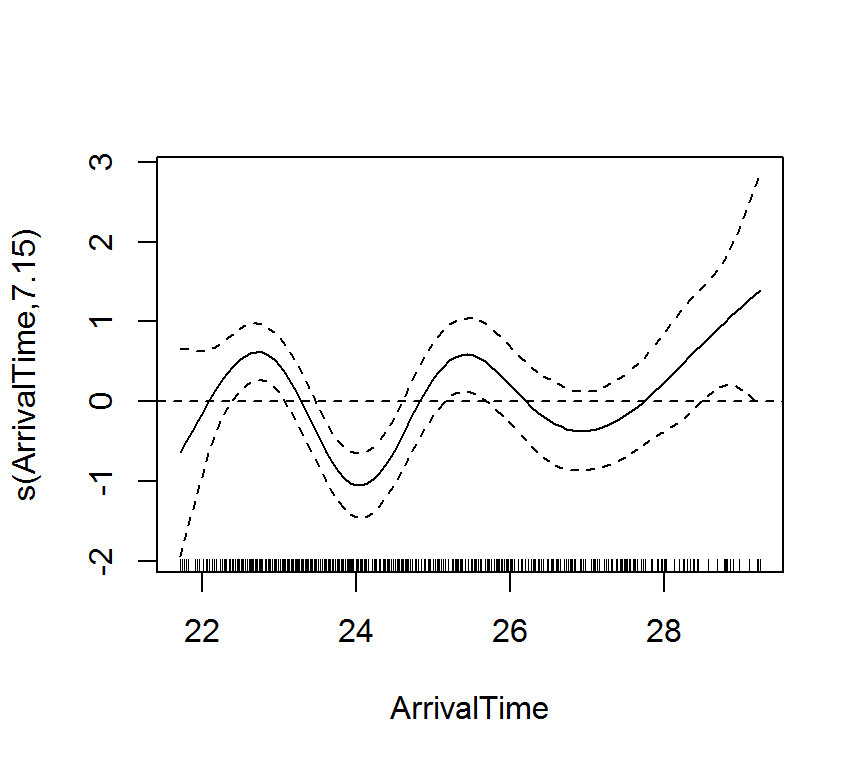

```r
plot(nonlin1)
abline(h = 0, lty = 2)
```

- Совершенно точно нужен GAMM. Но продолжим с GLMM

## У нас была сверхдисперсия. Пробуем NB GLMM

\[NCalls_{ij} = e^{\beta_0 + \beta_{1}SexP_{M} + \beta_{2}FoodT_{S} + \beta_{3}ArrivalT + \beta_{4} SexP_{M}:FoodT_{S} + \beta_{5}SexP{M}:ArrivalT + log(BroodSize) + a_{i} + \epsilon_{ij}}\]

- \(NCalls_{ij} \sim \boldsymbol{NB}(\mu_{ij}, k)\) — отклик подчиняется отрицательному биномиальному распределению с параметрами \(\mu\) и \(k\)
- \(E(NCalls_{ij}) = \mu_{ij}\)
- \(var(NCalls_{ij}) = \mu_{ij} + \mu^2_{ij} / k\)
- \(ln(\mu_{ij}) = \eta_{ij}\) — функция связи — логарифм

\(\begin{array}{l} \eta_{ij} = \beta_0 + \beta_{1}SexParent_{M} + \beta_{2}FoodTreatment_{S} + \beta_{3}ArrivalTime + \\ + \beta_{4} SexParent_{M}:FoodTreatment_{S} + \beta_{5}SexParent{M}:ArrivalTime + log(BroodSize) + \\ + a_{i} + \epsilon_{ij} \end{array}\)

- \(a_{i}\sim N(0, \sigma^2_{Nest})\) — случайный эффект гнезда (intercept)
- \(\epsilon_{ij} \sim N(0, \sigma^2)\) — остатки модели
- \(i\) — гнездо
- \(j\) — наблюдение

## Подберем NB GLMM

```r
M2 <- glmer.nb(NCalls ~ SexParent * FoodTreatment + SexParent * ArrivalTime_std + offset(logBroodSize) + (1 | Nest), data = Owls)
# # Если эта модель вдруг не сходится, есть обходной маневр. Можно попробовать заранее определить k  при помощи внутренней функции. В lme4 параметр k называется theta
# th <- lme4:::est_theta(M1)
# M2 <- update(M1, family = negative.binomial(theta=th))
```

## Задание:

Проверьте модель с отрицательным биномиальным распределением отклика

- на избыточность дисперсии
- наличие паттернов в остатках
- нелинейность паттернов в остатках

## Избыточность дисперсии (Overdispersion)

```r
R_M2 <- resid(M2, type = "pearson") # Пирсоновские остатки
N <- nrow(Owls) # Объем выборки
p <- length(fixef(M2)) + 1 + 1  # Число параметров в модели (тета и сигма для гнезда)
df <- (N - p) # число степенейсвободы
fi <- sum(R_M2^2) /df  #Величина fi показывает во сколько раз в среднем sigma > mu для данной модели
fi
```

```
## [1] 0.851
```

- Сносно

## Диагностика отр. биномиальной модели

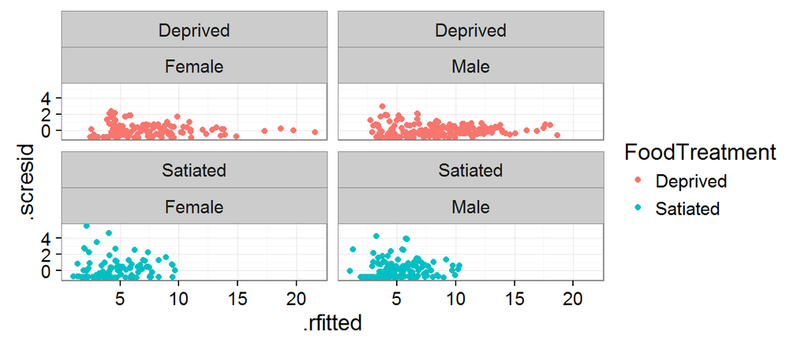

```r
M2_diag <- fortify(M2)
M2_diag$.rfitted <- predict(M2, type = "response")
gg_resid <- ggplot(M2_diag, aes(x = .rfitted, y = .scresid, colour = FoodTreatment)) + geom_point() + facet_wrap(~FoodTreatment + SexParent)
gg_resid
```

- Есть большие остатки

## Есть ли еще какие-то паттерны в остатках?

Может быть паттерны в остатках исчезли от того, что мы использовали другую GLMM?

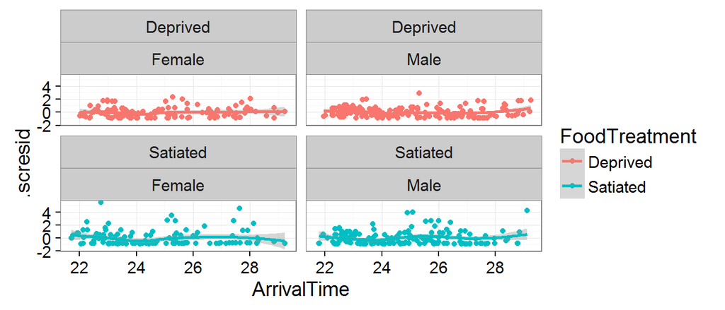

```r
# gg_resid %+% aes(x = ArrivalTime)
gg_resid %+% aes(x = ArrivalTime) + geom_smooth()
```

- Подозрительно. Возможно, нужен GAMM

## Проверяем, есть ли нелинейные паттерны

```r
nonlin2 <- gam(.scresid ~ s(ArrivalTime), data = M2_diag)
summary(nonlin2)
```

```
##
## Family: gaussian
## Link function: identity
##
## Formula:
## .scresid ~ s(ArrivalTime)
##
## Parametric coefficients:
##             Estimate Std. Error t value Pr(>|t|)
## (Intercept) -0.00121    0.03642   -0.03     0.97
##
## Approximate significance of smooth terms:
##                 edf Ref.df    F p-value
## s(ArrivalTime) 7.02    8.1 4.55 0.00002 ***
## ---
## Signif. codes:  0 '***' 0.001 '**' 0.01 '*' 0.05 '.' 0.1 ' ' 1
##
## R-sq.(adj) =  0.0552   Deviance explained = 6.63%
## GCV = 0.80535  Scale est. = 0.79456   n = 599
```

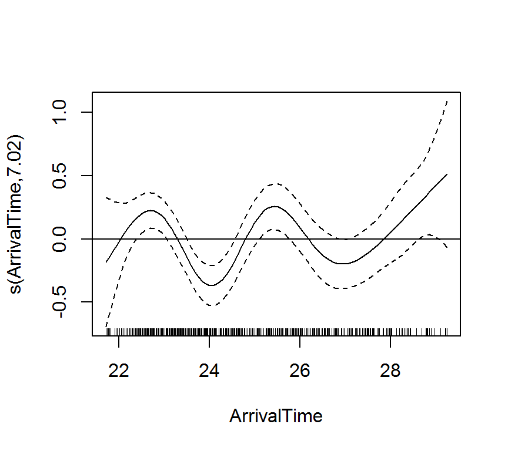

```r
plot(nonlin2)
abline(h = 0)
```

- Совершенно точно нужен GAMM

## Подбор оптимальной модели

Все ли достоверно?

```r
summary(M2)
```

```
## Generalized linear mixed model fit by maximum likelihood (Laplace
##   Approximation) [glmerMod]
##  Family: Negative Binomial(0.885)  ( log )
## Formula:
## NCalls ~ SexParent * FoodTreatment + SexParent * ArrivalTime_std +
##     offset(logBroodSize) + (1 | Nest)
##    Data: Owls
##
##      AIC      BIC   logLik deviance df.resid
##     3479     3514    -1732     3463      591
##
## Scaled residuals:
##    Min     1Q Median     3Q    Max
## -0.906 -0.779 -0.202  0.437  5.458
##
## Random effects:
##  Groups Name        Variance Std.Dev.
##  Nest   (Intercept) 0.109    0.33
## Number of obs: 599, groups:  Nest, 27
##
## Fixed effects:
##                                     Estimate Std. Error z value
## (Intercept)                          0.65564    0.12935    5.07
## SexParentMale                       -0.00996    0.14211   -0.07
## FoodTreatmentSatiated               -0.77082    0.16143   -4.77
## ArrivalTime_std                     -0.24911    0.07300   -3.41
## SexParentMale:FoodTreatmentSatiated  0.17793    0.20120    0.88
## SexParentMale:ArrivalTime_std        0.04979    0.09546    0.52
##                                      Pr(>|z|)
## (Intercept)                         0.0000004 ***
## SexParentMale                         0.94411
## FoodTreatmentSatiated               0.0000018 ***
## ArrivalTime_std                       0.00064 ***
## SexParentMale:FoodTreatmentSatiated   0.37652
## SexParentMale:ArrivalTime_std         0.60197
## ---
## Signif. codes:  0 '***' 0.001 '**' 0.01 '*' 0.05 '.' 0.1 ' ' 1
##
## Correlation of Fixed Effects:
##             (Intr) SxPrnM FdTrtS ArrvT_ SPM:FT
## SexParentMl -0.689
## FdTrtmntStt -0.605  0.550
## ArrvlTm_std  0.014 -0.008  0.048
## SxPrntM:FTS  0.450 -0.667 -0.744 -0.045
## SxPrntM:AT_ -0.004  0.004 -0.053 -0.752  0.042
```

## Можно ли что-то выкинуть

```r
drop1(M2, test = "Chi")
```

```
## Single term deletions
##
## Model:
## NCalls ~ SexParent * FoodTreatment + SexParent * ArrivalTime_std +
##     offset(logBroodSize) + (1 | Nest)
##                           Df  AIC   LRT Pr(Chi)
## <none>                       3479
## SexParent:FoodTreatment    1 3478 0.783    0.38
## SexParent:ArrivalTime_std  1 3478 0.272    0.60
```

- Если выкинуть взаимодействия, модель не станет хуже

## Выкидываем одно взаимодействие

```r
M3 <- update(M2, .~.-SexParent:ArrivalTime_std)
drop1(M3, test = "Chisq")
```

```
## Single term deletions
##
## Model:
## NCalls ~ SexParent + FoodTreatment + ArrivalTime_std + (1 | Nest) +
##     SexParent:FoodTreatment + offset(logBroodSize)
##                         Df  AIC   LRT   Pr(Chi)
## <none>                     3478
## ArrivalTime_std          1 3496 20.47 0.0000061 ***
## SexParent:FoodTreatment  1 3476  0.75      0.39
## ---
## Signif. codes:  0 '***' 0.001 '**' 0.01 '*' 0.05 '.' 0.1 ' ' 1
```

- теперь можно выкинуть второе

## Выкидываем второе взаимодействие

```r
M4 <- update(M3, .~.-SexParent:FoodTreatment)
drop1(M4, test = "Chisq")
```

```
## Single term deletions
##
## Model:
## NCalls ~ SexParent + FoodTreatment + ArrivalTime_std + (1 | Nest) +
##     offset(logBroodSize)
##                 Df  AIC  LRT       Pr(Chi)
## <none>             3476
## SexParent        1 3475  0.4           0.5
## FoodTreatment    1 3513 39.0 0.00000000043 ***
## ArrivalTime_std  1 3495 20.3 0.00000651759 ***
## ---
## Signif. codes:  0 '***' 0.001 '**' 0.01 '*' 0.05 '.' 0.1 ' ' 1
```

- теперь можно выкинуть пол родителя

```r
M5 <- update(M4, .~.-SexParent)
drop1(M5, test = "Chisq")
```

```
## Single term deletions
##
## Model:
## NCalls ~ FoodTreatment + ArrivalTime_std + (1 | Nest) + offset(logBroodSize)
##                 Df  AIC  LRT       Pr(Chi)
## <none>             3475
## FoodTreatment    1 3513 39.9 0.00000000027 ***
## ArrivalTime_std  1 3493 20.1 0.00000746455 ***
## ---
## Signif. codes:  0 '***' 0.001 '**' 0.01 '*' 0.05 '.' 0.1 ' ' 1
```

- это финальная модель

## Второй способ подбора оптимальной модели - AIC

```r
AIC(M2, M3, M4, M5)
```

```
##    df  AIC
## M2  8 3479
## M3  7 3478
## M4  6 3476
## M5  5 3475
```

## Модель изменилась. Нужно повторить диагностику

Избыточность дисперсии (Overdispersion)

```r
R_M5 <- resid(M5, type = "pearson") # Пирсоновские остатки
N <- nrow(Owls) # Объем выборки
p <- length(fixef(M5)) + 1 + 1  # Число параметров в модели (тета и сигма для гнезда)
df <- (N - p) # число степенейсвободы
fi <- sum(R_M5^2) /df  #Величина fi показывает во сколько раз в среднем sigma > mu для данной модели
fi
```

```
## [1] 0.844
```

- Сносно

## Диагностика отр. биномиальной модели

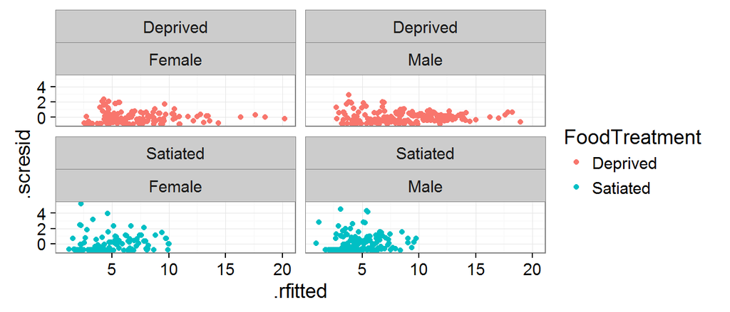

```r
M5_diag <- fortify(M5)
M5_diag$.rfitted <- predict(M5, type = "response")
gg_resid <- ggplot(M5_diag, aes(x = .rfitted, y = .scresid, colour = FoodTreatment)) + geom_point() + facet_wrap(~FoodTreatment + SexParent)
gg_resid
```

- Есть большие остатки

## Есть ли еще какие-то паттерны в остатках?

Может быть паттерны в остатках исчезли от того, что мы использовали другую GLMM?

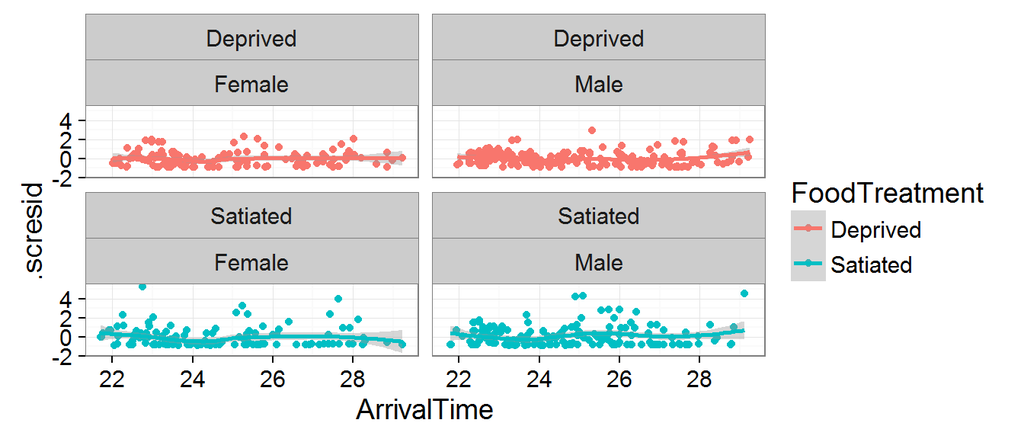

```r
# gg_resid %+% aes(x = ArrivalTime)
gg_resid %+% aes(x = ArrivalTime) + geom_smooth()
```

- Подозрительно. Возможно, нужен GAMM

## Проверяем, есть ли нелинейные паттерны

```r
nonlin5 <- gam(.scresid ~ s(ArrivalTime), data = M5_diag)
summary(nonlin5)
```

```
##
## Family: gaussian
## Link function: identity
##
## Formula:
## .scresid ~ s(ArrivalTime)
##
## Parametric coefficients:
##             Estimate Std. Error t value Pr(>|t|)
## (Intercept) -0.00119    0.03636   -0.03     0.97
##
## Approximate significance of smooth terms:
##                 edf Ref.df    F  p-value
## s(ArrivalTime) 6.99   8.07 4.61 0.000017 ***
## ---
## Signif. codes:  0 '***' 0.001 '**' 0.01 '*' 0.05 '.' 0.1 ' ' 1
##
## R-sq.(adj) =  0.0559   Deviance explained = 6.69%
## GCV = 0.80266  Scale est. = 0.79195   n = 599
```

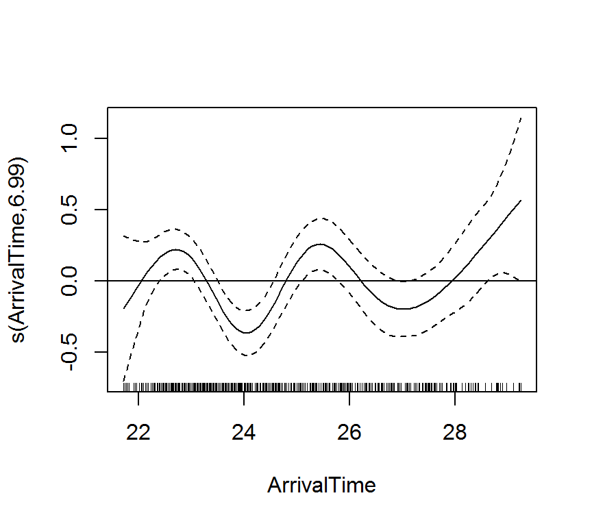

```r
plot(nonlin5)
abline(h = 0)
```

- Совершенно точно нужен GAMM
- Но мы продолжим

## Финальная GLMM, которую мы получили, выглядит так

- \(NCalls_{ij} \sim \boldsymbol{NB}(\mu_{ij}, k)\) — отклик подчиняется отрицательному биномиальному распределению с параметрами \(\mu\) и \(k\)
- \(E(NCalls_{ij}) = \mu_{ij}\)
- \(var(NCalls_{ij}) = \mu_{ij} + \mu^2_{ij} / k\)
- \(ln(\mu_{ij}) = \eta_{ij}\) — функция связи — логарифм

- \(a_{i}\sim N(0, \sigma^2_{Nest})\) — случайный эффект гнезда (intercept)
- \(\epsilon_{ij} \sim N(0, \sigma^2)\) — остатки модели
- \(i\) — гнездо
- \(j\) — наблюдение

## Готовим данные для графика модели

```r
library(plyr)
NewData <- ddply(Owls, .variables = .(FoodTreatment), summarise, ArrivalTime_std = seq(min(ArrivalTime_std),  max(ArrivalTime_std), length = 100))
NewData$ArrivalTime <- NewData$ArrivalTime_std * sd(Owls$ArrivalTime) + mean(Owls$ArrivalTime)
```

## Предсказания и ошибки

```r
# Модельная матрица
X <- model.matrix(~ FoodTreatment + ArrivalTime_std, data = NewData)
# К предсказанным значениям нужно прибавить оффсет. Мы будем делать предсказания для среднего размера выводка.
NewData$Pred <- X %*% fixef(M5) + log(mean(Owls$BroodSize))
# Стандартные ошибки предсказаний
NewData$SE <- sqrt(diag(X %*% vcov(M5) %*% t(X)))
```

## График предсказанных значений

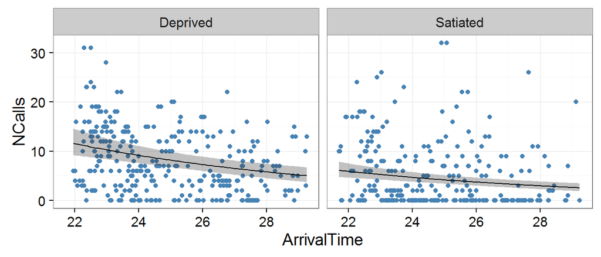

## Код для графика предсказанных значений

```r
ggplot() +
  geom_point(data = Owls, aes(x = ArrivalTime, y = NCalls), colour = "steelblue") +
  geom_ribbon(data = NewData, aes(x = ArrivalTime, ymax = exp(Pred + 1.96 * SE), ymin = exp(Pred - 1.96 * SE)), alpha = 0.3) +
  geom_line(data = NewData, aes(x = ArrivalTime, y = exp(Pred), group = FoodTreatment)) +
  facet_wrap(~FoodTreatment)
```

## Take home messages

- В случае счетных зависимых перменных (неотрицательных целочисленных величин) применяются модели, основанные на распределении Пуассона или отрицаетльном биномиальном распределении.
- При проверке на избыточность дисперсии таких смешанных линейных моделей, нужно учитывать дополнительные параметры: дисперсию связанную со случайными факторами, и параметр тета для отрицательного биномиального распределения
- Нелинейные паттерны в остатках иногда могут быть причиной избыточности (или недостатка) дисперсии.

## Дополнительные ресурсы

- Crawley, M.J. (2007). The R Book (Wiley).
- Zuur, A.F., Ieno, E.N., Walker, N., Saveliev, A.A., and Smith, G.M. (2009). Mixed Effects Models and Extensions in Ecology With R (Springer).